# Final Project

2026-04-17

# Reflection and Analysis of Final Data Visualization Project

For my final project, I decided to create a short report examining Chinese financing for transition mineral projects between 2000 and 2023. The project focused on minerals tied to the clean energy transition, including copper, cobalt, lithium, and nickel. These minerals are increasingly important because they are used in electric vehicles, batteries, renewable energy systems, and electrical infrastructure.

I chose this topic because of my interest in foreign policy. Transition minerals have become an important geopolitical and economic issue in the past few decades, and as countries are investing more heavily in clean energy, competition over access to critical minerals has increased. China already plays a major role in mining, mineral processing, and battery manufacturing, so I wanted to better understand how Chinese overseas financing fits into those broader trends.

The report used William & Mary AidData’s Tracking China’s Transition Mineral Financing, Version 2.0 dataset. I thought this dataset worked well because it included information about financing amounts, country locations, ownership structures, mining activities, and mineral types. This made it possible to examine Chinese financing from several different perspectives. It’s also a unique data set in that AidData tackled the difficult task of documenting China’s lending practices when China is intentionally opaque about them.

**Intended Audience and Design Choices** My intended audience was a general policy audience rather than a technical academic audience. I imagined the report being read by people interested in international foreign policy or economics, but who may not have a strong background knowledge of mineral supply chains or China’s influence in this sector. I tried to avoid overly technical language and focused on charts that could be interpreted relatively quickly.

I also wanted the report to feel more like a short policy or magazine-style report rather than a technical research paper. I used consistent colors and fairly simple layouts, as well as descriptive titles that for the most part communicated the main takeaway of each chart. I wanted the charts to be visually engaging without being overly complicated. Another goal was making the visualizations easy to compare with one another. I used a consistent color palette and font style across the report so the charts would feel connected as part of a broader narrative rather than separate graphics.

In several cases, I considered alternative chart types before deciding on the final designs. Some charts could have shown more detailed information, but I tried to prioritize readability and simplicity because of the intended audience.

I used a stacked horizontal bar chart because it made it possible to compare both total financing and financing structure at the same time. I considered using separate charts for financing totals and ownership, which may have made each variable easier to interpret individually. However, I ultimately decided that combining the information into one chart better demonstrated how financing structure varies across countries.

I also limited the chart to the top ten countries so the visualization would remain readable, and because there was a significant drop-off after the 10th country. I initially created a version of the chart that grouped the loans by collateralized and non-collateralized, but after playing around with different variables I decided I liked the story of exploring ownership instead. One limitation of this chart is that adding ownership information can distract from the main takeaway, which is simply identifying the countries receiving the largest amounts of financing.

**Waffle Plot** The waffle chart examined the distribution of ownership shares held by Chinese stakeholders in financed projects. The main takeaway was that most projects either involve majority Chinese ownership or no Chinese ownership at all. I chose a waffle chart because it clearly shows proportions and composition. Each circle represents one percent of projects, which makes the overall distribution easy to understand quickly. I also considered using a pie chart or a simple bar chart. A bar chart would have been more precise, but I thought the waffle chart was visually more engaging and communicated the “all or nothing” ownership pattern more effectively. I wanted to include a simple graphic that is relatively quick to interpret. I also simplified the ownership categories from the original dataset because the full categories made the chart feel too cluttered.

**Barbell Plot** The final major chart examined how Chinese financing priorities changed between 2010 and 2023 across different mining activities. The chart showed a major decline in financing for mine development alongside large increases in processing and mine acquisition. I chose a barbell chart because it clearly shows change over time across multiple categories. I considered using a grouped bar chart, but I thought the barbell chart made it easier to compare both the direction and magnitude of change between 2010 and 2023. The connecting lines between the points also helped emphasize the idea that financing priorities shifted significantly over time. I also used shares of total funding rather than absolute dollar amounts so the two years would be easier to compare.

**Effectiveness** Overall, I think the final product successfully communicated a broader story about Chinese financing for transition mineral projects. Instead of presenting unrelated charts, I tried to make each visualization contribute to a larger narrative about China’s growing role in transition mineral supply chains. One thing I am especially happy with is the consistency across the visualizations. I spent a lot of time refining the titles, colors, fonts, spacing, and legends so the report would feel more polished and cohesive. At the same time, some charts still contain a large amount of information, and additional annotations or explanatory text could make them easier for a general audience to interpret.

**Challenges** One of the biggest challenges in the project was data cleaning and preparation. Many variables required recoding and significant restructuring before I could plot them. Another challenge was balancing simplicity with detail. Many variables contained complicated information that was difficult to present clearly in a single chart. I also spent a significant amount of time refining the visual design of the charts. Small changes to margins, labels, legends, and annotations often took a surprisingly long time. Finally, it was challenging to make sure the report told a coherent story rather than simply presenting separate visualizations. I wanted the project to feel like a connected narrative about Chinese financing priorities and transition mineral supply chains.

```r
head(loan_events)
```

[output not shown]

[output cut: 90 more lines]

## PLOT 1: TIMELINE RIBBON

Data preparation

```r
mineral_timeline <- loan_events %>%
  select(commitment_year, transition_minerals) %>%
  filter(!is.na(transition_minerals), transition_minerals != "") %>%
  mutate(loan_id = row_number()) %>%
  separate_rows(transition_minerals, sep = "\\|") %>%
  mutate(transition_minerals = str_trim(transition_minerals),
         transition_minerals = recode(
              transition_minerals,
              "Graphite" = "Natural Graphite")) %>%

  # filter to USGS list
  filter(transition_minerals %in% c("Copper","Cobalt","Nickel","Lithium","Platinum","Iridium","Gallium","Magnesium", "Silicon","Natural Graphite")) %>%
  distinct(loan_id, commitment_year, transition_minerals) %>%
  count(commitment_year, transition_minerals, name = "num_loans")

# order the minerals by number of loan events in 2023
order2023 <- mineral_timeline %>% filter(commitment_year == 2023) %>%
     arrange(num_loans) %>%
     pull(transition_minerals)

# apply ordering to dataset
mineral_timeline <- mineral_timeline %>%
  mutate(transition_minerals = factor(transition_minerals, levels = order2023))
```

```r
mineral_timeline <- loan_events %>%
  select(commitment_year, transition_minerals) %>%
  filter(!is.na(transition_minerals), transition_minerals != "") %>%
  mutate(
    loan_id = row_number(),
    commitment_year = as.numeric(commitment_year)) %>%
  separate_rows(transition_minerals, sep = "\\|") %>%
  mutate(
    transition_minerals = str_trim(transition_minerals),
    transition_minerals = str_to_title(transition_minerals),
    transition_minerals = recode(
      transition_minerals,
      "Graphite" = "Natural Graphite")) %>%

  filter(transition_minerals %in% c(
    "Copper",
    "Cobalt",
    "Nickel",
    "Lithium",
    "Platinum",
    "Iridium",
    "Gallium",
    "Magnesium",
    "Silicon",
    "Natural Graphite")) %>%

  distinct(loan_id, commitment_year, transition_minerals) %>%
  count(commitment_year, transition_minerals, name = "num_loans")
```

```r
minerals <- sort(unique(mineral_timeline$transition_minerals))

#calculate 3-year rolling average
mineral_timeline <- mineral_timeline %>%
  arrange(transition_minerals, commitment_year) %>%
  group_by(transition_minerals) %>%
  mutate(num_loans_smooth = zoo::rollmean(num_loans, k = 2, fill = NA, align = "center")) %>%
  ungroup()

# create randomized viridis color palette
set.seed(148) # 148, 165
colors <- sample(viridis(length(minerals), option = "mako"))
names(colors) <- minerals
```

possible annotations 2008 – Global Financial Crisis 2015 – Paris Agreement 2018 – US–China trade tensions 2020 – COVID-19 / China carbon neutrality pledge 2022 – Inflation Reduction Act

[figure not shown]

```r
plot1 <- ggplot(mineral_timeline, aes(x = commitment_year, y = num_loans_smooth, fill = transition_minerals)) +
     geom_area(na.rm = TRUE) +
     scale_fill_manual(values = colors) +

     labs(title = "Chinese Critical Mineral Lending Surged After 2010",
          x = NULL,
          y = "Number of Loans",
          fill = "Mineral",
          subtitle = "Annual loan commitments for transition mineral projects, 2000–2023",
          caption = "Includes minerals designated as critical to the clean energy transition by USGS and DOE.") +

     theme_minimal(base_family = "roboto") +
     theme(text = element_text(color = "black"),
           plot.title.position = "plot",
          plot.title = element_text(face = "bold", size = 17),
          axis.text.x = element_text(size = 11, color = "gray10"),
          axis.text.y = element_text(size = 11, color = "gray10"),
          axis.title.y = element_text(size = 11, margin = margin(r = 8, l = 8)),
          panel.grid.minor.x = element_blank(),
          panel.grid.minor.y = element_blank(),
          plot.caption = element_text(hjust = 0, face = "italic", color = "gray20"),
          plot.caption.position = "plot",
          plot.background = element_rect(fill = "#F3F8FC", color = NA),
          legend.title = element_text(face = "bold"),
          legend.text = element_text(size = 10)
          )

    # annotate("text", x = 2020, y = 2, label = "COVID-19", vjust = 1.5, size = 3) +
    # annotate("text", x = 2013, y = 3, label = "BRI \nannounced", vjust = 1.5, size = 3, lineheight=.6) +
    # annotate("text", x = 2015, y = 3, label = "Paris \nAgreement", vjust = 1.5, size = 3, lineheight = .6)



plot1
```

## PLOT 2: BAR PLOT BY COUNTRY

```r
# rename variable
loan_events$amount <- loan_events$chinese_official_funding_amount_constant_usd_2023
# convert amount to numeric variable
loan_events <- loan_events %>% mutate(amount = parse_number(amount))

# shorten DRC name
loan_events <- loan_events %>%
  mutate(country_of_activity = if_else(
      country_of_activity == "Democratic Republic of the Congo",
      "Congo, Dem. Rep",
      country_of_activity))

# select top 10 countries by total funding amount
top_country_names <- loan_events %>%
     select(country_of_activity, amount) %>%
     filter(!is.na(country_of_activity), !is.na(amount)) %>%
     group_by(country_of_activity) %>%
     summarise(total_funding = sum(amount, na.rm = TRUE), .groups = "drop") %>%
     arrange(desc(total_funding)) %>%
     slice_head(n = 10) %>%
     pull(country_of_activity)

# summarize funding by country and Chinese ownership status
top_countries <- loan_events %>%
     select(country_of_activity,
            amount,
            chinese_control_of_mineral_products) %>%
     filter(!is.na(country_of_activity), !is.na(amount)) %>%
     mutate(chinese_control_of_mineral_products = case_when(
          chinese_control_of_mineral_products == "No" ~ "No Significant Ownership",
          chinese_control_of_mineral_products == "Yes" ~ "Significant Ownership")) %>%

     filter(country_of_activity %in% top_country_names) %>%
     group_by(country_of_activity, chinese_control_of_mineral_products) %>%

     # calculate total funding amount for each ownership category within each country.
     summarise(total_funding = sum(amount, na.rm = TRUE), .groups = "drop")
```

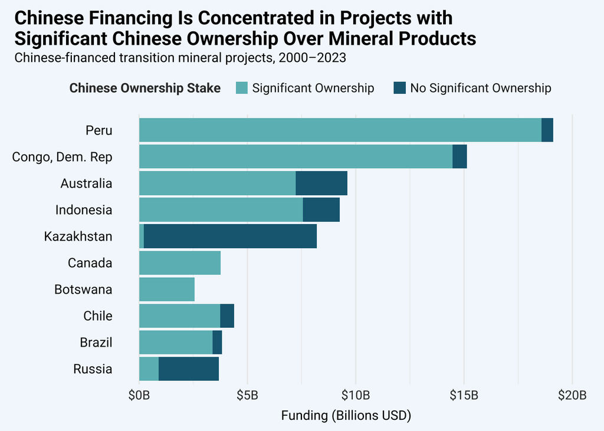

```r
plot2 <- ggplot(top_countries, aes(x = reorder(country_of_activity, total_funding),
                                   y = total_funding,
                                   fill = chinese_control_of_mineral_products)) +

  geom_col() +
  coord_flip() +
  scale_y_continuous(labels = scales::label_dollar(scale = 1e-9, accuracy = 1, suffix = "B")) +
  scale_fill_manual(values = c(
    "Significant Ownership" = "#6BBBBF",
    "No Significant Ownership" = "#1A6882")) +

     # change size of legend symbols
     guides(fill = guide_legend(reverse = TRUE,
          keywidth = unit(0.4, "cm"),
          keyheight = unit(0.4, "cm"))) +

     labs(title = "Chinese Financing Is Concentrated in Projects with \nSignificant Chinese Ownership Over Mineral Products",
          subtitle = "Chinese-financed transition mineral projects, 2000–2023",
          x = "",
          y = "Funding (Billions USD)",
          fill = "Chinese Ownership Stake") +

     theme_minimal(base_family = "roboto") +
     theme(text = element_text(color = "black"),
           plot.title.position = "plot",
           plot.title = element_text(face = "bold", size = 16, hjust = 0, margin = margin(l = 15, t = 9)),
           plot.subtitle = element_text(margin = margin(l = 15, t = 3, b = 3)),

           panel.grid.major.y = element_blank(),
           axis.text.y = element_text(size = 11, color = "gray5"),
           axis.text.x = element_text(size = 10.5, color = "gray20"),

           legend.text = element_text(size = 10.5, color = "gray10",
                                      margin = margin(l = 3,  r = 10)),
           legend.title = element_text(face = "bold", color = "gray20",
                                       margin = margin(r = 12)),
           legend.box.margin = margin(t = 5, r = 50),
           legend.position = "top",

           plot.background = element_rect(fill = "#F3F8FC", color = NA),
           plot.margin = margin(r = 25, l = -3),
           axis.title.x = element_text(margin = margin(t = 7, b = 7))
     )

plot2
```

## PLOT 3: WAFFLE CHART

```r
# reduce ownership categories
loan_events <- loan_events %>%
  mutate(level_of_chinese_ownership_clean = case_when(
       str_detect(level_of_chinese_ownership, "No Significant") ~ "No Chinese Ownership",
       str_detect(level_of_chinese_ownership, "Significant") ~ "Significant Chinese Ownership",
       str_detect(level_of_chinese_ownership, "Majority") ~ "Majority Chinese Ownership",
       TRUE ~ NA_character_))

# convert data to format for waffle chart
waffle_data_ownership_clean <- loan_events %>%
  mutate(level_of_chinese_ownership_clean = na_if(level_of_chinese_ownership_clean, "")) %>%
  filter(!is.na(level_of_chinese_ownership_clean)) %>%
  count(level_of_chinese_ownership_clean) %>%
  mutate(
    level_of_chinese_ownership_clean = recode(
      level_of_chinese_ownership_clean,
      "No Chinese Ownership" = "None",
      "Significant Chinese Ownership" = "Minority",
      "Majority Chinese Ownership" = "Majority")) %>%

  mutate(level_of_chinese_ownership_clean = factor(
       level_of_chinese_ownership_clean,
       levels = c("None", "Minority", "Majority"))) %>%
     arrange(level_of_chinese_ownership_clean) %>%
     mutate(pct = n / sum(n),
            units = round(pct * 100))

# ensure total adds to 100
waffle_data_ownership_clean$units[1] <- waffle_data_ownership_clean$units[1] +
  (100 - sum(waffle_data_ownership_clean$units))

waffle_plot_ownership_clean <- waffle_data_ownership_clean %>%
  uncount(units) %>%
  mutate(square = row_number(),
         row = ceiling(square / 10),
         col = square - (row - 1) * 10) %>%
     mutate(col = col * 1.35, row = row * 1.35) # control spacing between points


ownership_clean_colors <- c(
     "None" = "#DBD5D5",
     "Minority" = "#6BBBBF",
     "Majority" = "#1A6882")
```

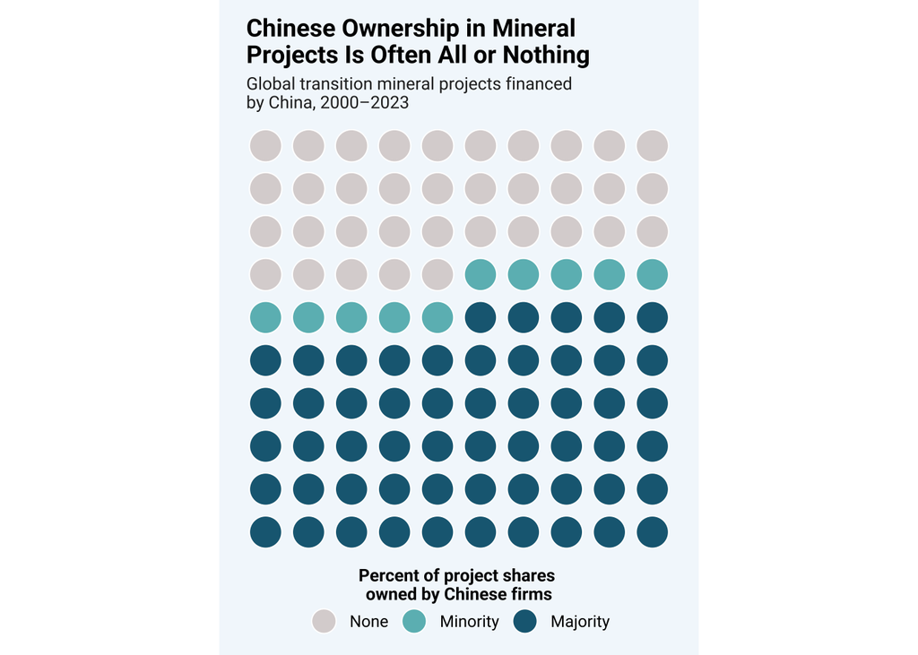

```r
plot3 <- ggplot(waffle_plot_ownership_clean, aes(x = col, y = -row,
                                                 fill = level_of_chinese_ownership_clean)) +
     geom_point(shape = 21, size = 8, color = "white", stroke = 0.5) +

     coord_equal(clip = "off") +

     scale_fill_manual(values = ownership_clean_colors) +

     labs(title = "Chinese Ownership in Mineral \nProjects Is Often All or Nothing",
       subtitle = "Global transition mineral projects financed \nby China, 2000–2023",
       fill = "Percent of project shares \nowned by Chinese firms") +

     guides(fill = guide_legend(
          title.position = "top", override.aes = list(size = 6))) +

  theme_void(base_family = "roboto") +
  theme(legend.text = element_text(color = "black", size = 9),
        legend.title = element_text(color = "black", size = 9.5, face = "bold", hjust = 0.5, margin = margin(b = 2)),
        legend.box.margin = margin(t = 3),
        legend.position = "bottom",
        plot.title = element_text(face = "bold", color = "black", hjust = 0, size = 13.5),
        plot.title.position = "plot",
        plot.background = element_rect(fill = "#F3F8FC", color = NA),
        plot.margin = margin(r = 15, l = 15, t = 5, b = 10),
        plot.subtitle = element_text(size = 9.5, color = "gray15",
                                     margin = margin(t = 5, b = 8))
  )

plot3
```

## PLOT 4: BARBELL

Data preparation

```r
barbell_data <- loan_events %>%
     mutate(
          primary_mining_activity = na_if(primary_mining_activity, ""), # convert blanks to NA

        primary_mining_activity = recode( # rename "Working Capital" category
             primary_mining_activity, "Working Capital" = "Operational Support"),

        # add line breaks between category words
        primary_mining_activity = str_replace_all( primary_mining_activity," ","\n"),

        funding_amount = parse_number(chinese_official_funding_amount_constant_usd_2023)) %>% # convert to numeric


     # keep only valid observations from 2010 and 2023
     filter(commitment_year %in% c(2010, 2023),
            !is.na(primary_mining_activity), !is.na(funding_amount)) %>%

     # calculate total funding by activity and year
     group_by(commitment_year, primary_mining_activity) %>%
     summarise(funding_amount = sum(funding_amount),
               .groups = "drop") %>% # remove groupings

     # convert totals into shares of yearly funding
     group_by(commitment_year) %>%
     mutate(pct = funding_amount / sum(funding_amount)) %>%
     ungroup() %>%

     # keep only these columns
     select(primary_mining_activity, commitment_year, pct ) %>%

     # reshape to wide format
     pivot_wider(names_from = commitment_year,
                 values_from = pct, names_prefix = "year_") %>%
     drop_na() %>%

  mutate(
       change = year_2023 - year_2010, #calculate difference between 2023 and 2010 shares

       # order by magnitude of change
       primary_mining_activity = fct_reorder(primary_mining_activity, change),

       # start the arrowhead slightly before or after endpoint
       arrow_start = if_else(change < 0, year_2023 + 0.01,
                             year_2023 - 0.01),
       arrow_end = year_2023) %>%

  # order categories by amount of change
  arrange(change) %>%

  # keep the order
  mutate(primary_mining_activity = factor(
       primary_mining_activity,
       levels = primary_mining_activity))

barbell_data
```

```
## # A tibble: 4 × 6
##   primary_mining_activity year_2010 year_2023 change arrow_start arrow_end
##   <fct>                       <dbl>     <dbl>  <dbl>       <dbl>     <dbl>
## 1 "Mine\nDevelopment"        0.666     0.0659 -0.600      0.0759    0.0659
## 2 "Operational\nSupport"     0.167     0.278   0.112      0.268     0.278
## 3 "Mine\nAcquisition"        0.114     0.319   0.205      0.309     0.319
## 4 "Processing"               0.0525    0.291   0.238      0.281     0.291
```

Plot

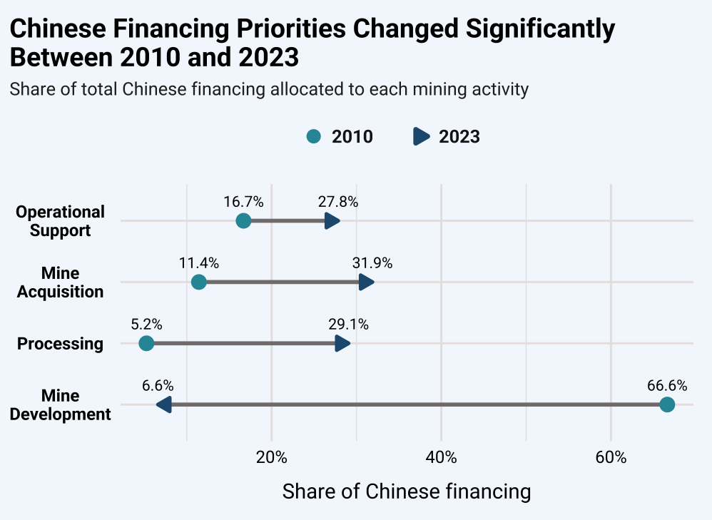

```r
plot4 <- ggplot(barbell_data, aes(y = reorder(primary_mining_activity, -abs(change)))) + # order by change, smallest to largest

     # connecting line
     geom_segment(aes(x = year_2010, xend = year_2023,
                      yend = primary_mining_activity),
                  color = "#837D7D", linewidth = 1) +

     # arrowheads for 2023
     geom_segment(aes(x = arrow_start, xend = arrow_end,
                      yend = primary_mining_activity,
                      color = "2023"),
               linewidth = 0.9,
               arrow = arrow(
                    type = "closed",
                    ends = "last", # arrowhead appears at xend (2023)
                    length = unit(0.1, "inches"))) + # size of arrowhead

     # 2010 points
     geom_point(aes(x = year_2010,
                    color = "2010"), size = 3.2) +

     # 2010 percentage labels
     geom_text(aes(x = year_2010, label = percent(year_2010, accuracy = 0.1)),
               vjust = -1.3, size = 2.8, color = "black") +

     # 2023 percentage labels
     geom_text(aes(x = year_2023, label = percent(year_2023, accuracy = 0.1)),
               vjust = -1.3, size = 2.8, color = "black") +

     # assign colors for 2010 points and 2023 arrows
     scale_color_manual(
          name = NULL,
          values = c("2010" = "#2B96A6", "2023" = "#215A80")) + #63B6BA

     # remove/customize legend items
     guides(color = guide_legend(override.aes = list(
          linetype = c(0, 1),
          shape = c(16, NA),
          linewidth = c(0, 1.2)))) +

     # format x-axis as percentages
     scale_x_continuous(labels = percent_format()) +

     # labels
     labs(title = "Chinese Financing Priorities Changed Significantly \nBetween 2010 and 2023",
          subtitle = "Share of total Chinese financing allocated to each mining activity",
          x = "Share of Chinese financing",
          y = NULL) +

  theme_minimal(base_family = "roboto") +
  theme(
    plot.title = element_text(face = "bold", hjust = 0, size = 14),
    plot.title.position = "plot",
    axis.text = element_text(size = 9, color = "black"),
    legend.position = "top",
    plot.background = element_rect(fill = "#F3F8FC", color = NA),
    axis.title.x = element_text(margin = margin(t = 9, b = 9)),
    axis.text.y = element_text(hjust = 0.5, face = "bold"),
    plot.margin = margin(r = 10, t = 10, l = 5),
    panel.grid.major = element_line(color = "#E8E3E3"),
    panel.grid.minor = element_line(color = "#E8E3E3"),
    plot.subtitle = element_text(size = 9.5, color = "gray15"),

    # reduce spacing between legend items and labels
    legend.key.width = unit(0.32, "cm"),
    legend.text = element_text(size = 9.5, face = "bold", color = "gray10", margin = margin(l = 5, r = 15))
    )

plot4
```

##PLOT 5: REGIONAL MAP

Dataset with top regions

```r
# load world map shapefile as sf object
world <- ne_countries(scale = "medium", returnclass = "sf")

# create new variable with ISO3 country codes
loan_events$country_code <- loan_events$country_of_activity_iso3 # rename original variable to match map dataset

# datset with loan amounts by country
loan_country_totals <- loan_events %>%
     group_by(country_code) %>%
     summarise(total_amount = sum(amount, na.rm = TRUE), # calculate loan total per country
               .groups = "drop") %>%

  # convert loan values to billions
  mutate(total_billions = total_amount / 1e9)

# create summary table of loans by world region
regional_summary <- world %>%
     st_drop_geometry() %>% # remove geometry column
     filter(subregion != "Antarctica") %>% # exclude antarctica
     select(iso_a3, subregion) %>% # keep only ISO code & subregion columns
     left_join(loan_country_totals, by = c("iso_a3" = "country_code")) %>%

     # create custom regions
     mutate(custom_region = case_when(
          subregion %in% c("Australia and New Zealand", "Melanesia", "Micronesia", "Polynesia") ~ "Oceania",
          subregion == "Northern America" ~ "North America",
          subregion %in% c("Caribbean", "Central America", "South America") ~ "Latin America",
          subregion %in% c("Eastern Africa", "Middle Africa", "Southern Africa", "Western Africa") ~ "Sub-Saharan Africa",
          subregion == "South-Eastern Asia" ~ "South East Asia",
          subregion == "Central Asia" ~ "Central Asia",
          TRUE ~ "Other")) %>%

     # put all country data into one row per region
  group_by(custom_region) %>%
     summarise(
          total_loans = sum(total_amount, na.rm = TRUE),
          total_billions = total_loans / 1e9,
          countries_with_loans = sum(!is.na(total_amount)),
          .groups = "drop") %>%
      arrange(desc(total_billions))
```

Create annotations with top region names and loan values

```r
top_regions <- regional_summary %>%
  filter(custom_region != "Other") %>%
  arrange(desc(total_billions)) %>%
  mutate(total_label = paste0("$", round(total_billions, 1), "B")) # format $ amount

top_regions_text <- top_regions %>%
  mutate(line = paste0( # creates one line for each region
       custom_region,
       strrep("&nbsp;", 6), # add horizontal space
       "<span style='color:#363252;'><b>",
       total_label,
       "</b></span>")) %>%

  pull(line) %>% # grab only formatted line column
  paste(collapse = "<br>") # combine all lines and add line breaks

# add title "Top Regions"
annotation_text <- paste0(
     "<b>Top Regions</b><br>",
     top_regions_text)

# create text with only region names
region_names_text <- top_regions %>%
  pull(custom_region) %>%
  paste(collapse = "\n") # add line breaks between region names

# create tect with only loan values
region_values_text <- top_regions %>%
  pull(total_label) %>%
  paste(collapse = "\n") # add line breaks between values
```

```r
# join loan and world map data
world_loans <- world %>%
     filter(continent != "Antarctica") %>% # remove antarctica from map

  # join to the map using ISO3 codes
     left_join(loan_country_totals,
            by = c("iso_a3" = "country_code")) %>%

     # create categories based on loan amounts
     mutate(
          loan_category = cut(total_billions,
                              breaks = c(0, 1, 5, 10, 20), #define breaks (in billions $)
                              labels = c("$0–1B", # create category labels
                                         "$1–5B",
                                         "$5–10B",
                                         "$10–20B"),
                              include.lowest = TRUE), # include countries with exactly 0 or 1 in first category

          # replace countries with NA values with "No loans" so they can appear on map
          loan_category_map = fct_na_value_to_level(
               loan_category,
               level = "No loans"))


# assign colors to each loan category
loan_colors <- c(
     "$0–1B" = "#9DDED3",
     "$1–5B" = "#74B2B6",
     "$5–10B" = "#237B8D",
     "$10–20B" = "#1D5787")

# add color for countries with no loans
loan_colors_map <- c(
     loan_colors,
     "No loans" = "#EDE5E5")
```

Plot 5

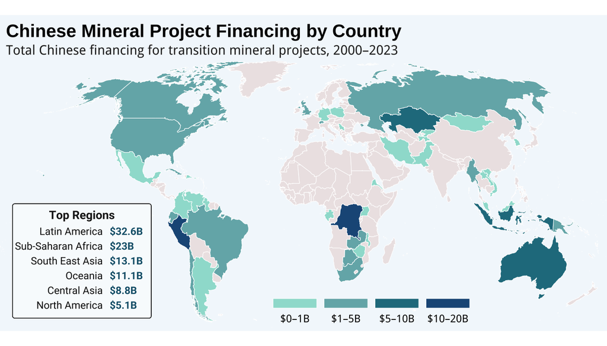

```r
plot5 <- ggplot(world_loans) +
  geom_sf(aes(fill = loan_category_map), color = "white", linewidth = 0.2) +
     # change projection
     coord_sf(crs = "+proj=robin",
              default_crs = sf::st_crs(4326),
              expand = FALSE) + # remove extra blank space around map

     # create box to fill with annotation text
     annotate(
          "label",
          x = -175, y = -24,
          label = "Top Regions\n\n\n\n\n", # add line breaks to create vertical space inside box
          hjust = 0,
          vjust = 0.5,
          fill = "#F8FBFD",
          color = "gray10", # text color
          fontface = "bold",
          label.size = 0.25, # box border thickness
          label.padding = unit(c(0.5, 2.6, 1.1, 2.6), "lines"), # padding around "Top Regions"
          family = "roboto",
          size = 3.4) + # text side

     # add region names inside box
     annotate(
          "text",
          x = -119, y = -7,
          label = region_names_text,
          hjust = 1,
          vjust = 1,
          family = "roboto",
          color = "gray5", # text color
          size = 3,
          lineheight = 1.2,) +

     # add loan values next to region names
     annotate(
          "text",
          x = -115, y = -7,
          label = region_values_text,
          hjust = 0,
          vjust = 1,
          family = "roboto",
          fontface = "bold",
          color = "#115F78",
          size = 3,
          lineheight = 1.2) +

     # add custom colors
     scale_fill_manual(
          values = loan_colors_map,
          breaks = names(loan_colors),
          name = NULL) +

     # customize legend formatting
     guides(
          fill = guide_legend(
               direction = "horizontal",
               label.position = "bottom", # place labels below color boxes
               keywidth = unit(1.3, "cm"), # width of each legend symbol
               keyheight = unit(0.3, "cm"), # height of each legend symbol
               nrow = 1, # put all legend items in one row
               byrow = TRUE)) +

     labs(title = "Chinese Mineral Project Financing by Country",
          subtitle = "Total Chinese financing for transition mineral projects, 2000–2023") +

     theme_void() +
     theme(
          plot.title = element_text(face = "bold", size = 15, margin = margin(l = 5, t = 3)),
          plot.subtitle = element_text(color = "gray15", margin = margin(l = 5, t = 4, b = 3)),
          legend.position = c(0.6, 0.06),
          legend.spacing.x = unit(0, "cm"),
          legend.key = element_rect(color = NA),
          plot.background = element_rect(fill = "#F3F8FC", color = NA),
          plot.margin = margin(t = 5, b = 3, r = -10))
plot5
```